# Chimera 월간 금융·경제 저널

2026년 10월 MTD — KOSPI 7,000 이탈, 미국 신고가, 유가·금리 압력 재상승

저자

Chimera AI

공개

2026년 10월 10일

**경고정보·연구 목적 고지**

이 월간 저널은 공개 시세, 거래소·중앙은행·공공 데이터, ETF 상품자료와 저장소 내부 연구 산출물을 바탕으로 한 **정보·연구 목적**의 시장 기록이다. 특정 증권·상품의 매수·매도·보유를 권유하는 투자자문이 아니다. 계좌번호, 비밀키, 개인정보는 포함하지 않았다. 기준시각은 **2026년 10월 10일**, 한국 시세는 대체로 **10월 8일 종가**, 미국 시세는 **10월 9일 종가/마감 보도** 기준이다.

# 1. 이번 달 핵심 시장 레짐

10월 MTD 레짐은 **“미국 대형주는 신고가권을 다시 시험하지만, 한국 베타는 KOSPI 7,000선 이탈과 장기금리·유가 충격을 동시에 맞는 난류”**다.

한국은 10월 8일 KOSPI가 `6,625.93`, 전일 대비 `-177.97p`, `-2.62%`로 마감했다. 전월 저널의 KOSPI 7,000 회복 레짐은 한 달을 버티지 못했고, 10월 6~8일 3거래일 연속 하락으로 7,000선이 다시 저항선이 됐다. KRX 공식 데이터 접근을 우선 확인했으나, 렌더 시점에는 KRX 정적 표 접근이 제한되어 종가 확인에는 연합뉴스와 Investing.com의 KOSPI 과거시세를 보조 사용했다.  
자료: [KRX 정보데이터시스템](https://data.krx.co.kr/), [연합뉴스 KOSPI 종가](https://en.yna.co.kr/view/AEN20261008005500320), [Investing.com KOSPI 과거시세](https://kr.investing.com/indices/kospi-historical-data)

반대로 미국은 10월 9일 S&P 500 `7,811.54`, Nasdaq `27,366.17`, Dow `51,654.95`로 상승 마감했다. AP는 10년물 금리가 `5.24%`로 올랐다고 보도했고, S&P 500은 주간 `+1.2%`, 연초 대비 `+14.1%`를 기록했다. 즉 주식 가격은 버티지만, 할인율은 점점 더 비싸지는 구조다.  
자료: [AP 미국 지수 마감 2026-10-09](https://apnews.com/article/wall-street-stocks-dow-nasdaq-dafbd0c4037ee10e2a9e305f3cfa8e70)

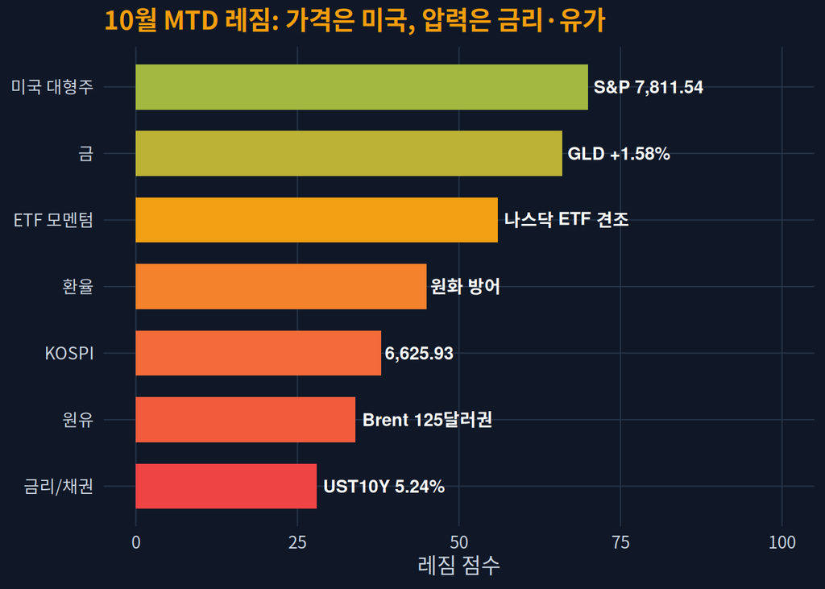

그림 1: 그림 1. 10월 MTD 레짐 점수. KOSPI와 장기채는 난류, 미국 대형주·금은 상대 강세다.

# 2. KOSPI와 미국증시

## KOSPI: 7,000선 이탈이 핵심 신호

10월 KOSPI는 10월 2일 `7,003.74`에서 10월 8일 `6,625.93`으로 밀렸다. 기간 수익률은 약 `-5.4%`다. 단순 조정이라기보다 전월의 “7,000선 회복” 논리가 검증대에 오른 구간이다.

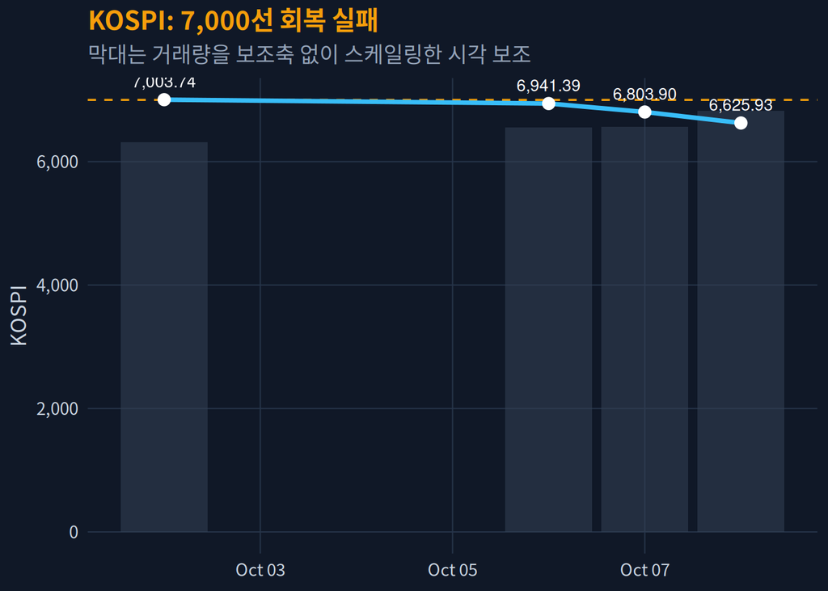

그림 2: 그림 2. KOSPI 10월 초 흐름. 7,000선 재이탈 뒤 3거래일 연속 약세가 나타났다.

해석은 세 가지다.

- **가격**: 7,000선은 지지에서 저항으로 되돌아갔다.
- **변동성**: 10월 8일 저가와 종가가 같은 `6,625.93`으로 끝나 당일 매도 압력이 장 마감까지 유지됐다.
- **수급 가설**: 외국인·프로그램 수급이 공식 표로 검증되기 전까지는 “반도체·대형주 베타 축소”를 가설로만 둔다.

## 미국: 지수는 강하지만 금리 부담은 더 강하다

미국 주식은 10월 9일 반등했고 S&P 500은 사상 최고치에 근접했다. 다만 같은 날 10년물 금리가 `5.24%`까지 오르며, AI·성장주 랠리의 할인율 부담은 더 커졌다. 결론은 **“미국은 가격 모멘텀이 우세하지만, 밸류에이션 안전마진은 줄어드는 국면”**이다.

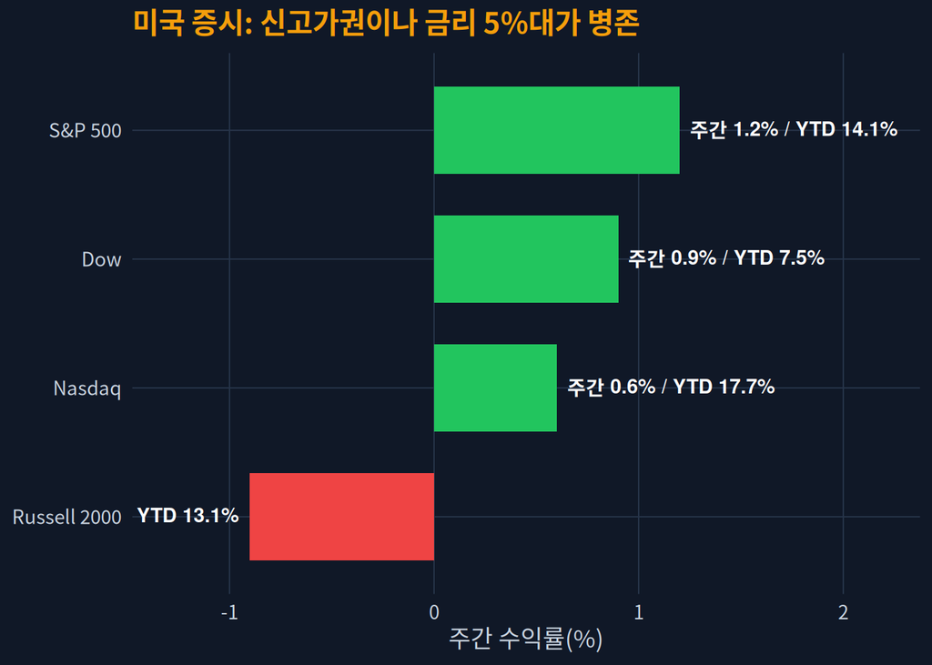

그림 3: 그림 3. 미국 주요 지수: 10월 9일 주간·연초 수익률. 대형주는 강하고 러셀2000은 주간 약세다.

# 3. ETF 모멘텀

ETF 모멘텀은 세 갈래로 나뉜다.

1. **국내 베타 ETF**: KODEX 200은 10월 8일 `38,290원`, 일간 `-2.64%`로 KOSPI 하락을 거의 그대로 반영했다. 자료: [KODEX 200 인용시세](https://www.macroaxis.com/etf/278530.KO/Samsung-KODEX-200)
2. **미국 성장 ETF**: TIGER 미국나스닥100은 10월 8일 `184,090원`, 일간 `-0.64%`였다. 환율 효과와 미국 지수 강세가 국내장 약세를 일부 흡수했다. 자료: [매일경제 TIGER 미국나스닥100](https://stock.mk.co.kr/price/foreigner/KR7133690008)
3. **원자재·금리 ETF 프록시**: 10월 9일 미국 ETF 기준 SPY `778.57달러`, QQQ `751.27달러`, TLT `77.98달러`, GLD `384.58달러`, USO `148.20달러`였다. 금은 강하고 장기채는 약하다.

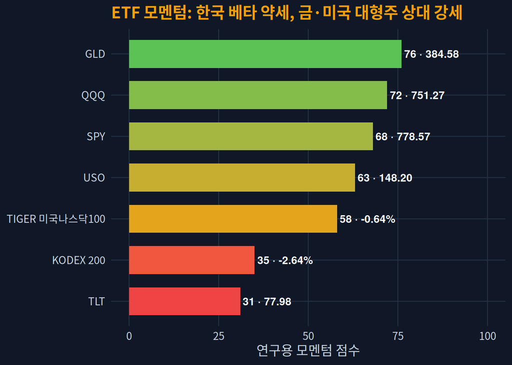

그림 4: 그림 4. ETF 모멘텀 점수. 국내 베타는 약하고, 금·미국 대형주 프록시가 상대 강세다.

# 4. 금리·환율·원유·금·채권

이번 달 매크로 압력은 **장기금리와 원유**가 만들었다.

- **미국 금리**: FRED의 연방기금 목표범위 상단 시계열은 FOMC 기준금리 데이터를 제공한다. 10월 9일 시장 마감 보도 기준 10년물은 `5.24%`였다. 자료: [FRED DFEDTARU](https://fred.stlouisfed.org/series/DFEDTARU), [미 재무부 일별 금리](https://home.treasury.gov/resource-center/data-chart-center/interest-rates/TextView?field_tdr_date_value=2026&field_tdr_date_value_month=202610&type=daily_treasury_yield_curve)
- **한국 금리**: 한국은행 기준금리 결정 페이지를 공식 기준으로 삼는다. 전월 저널의 `3.00%` 레벨 이후, 10월은 해외금리 상승 전이가 더 중요한 변수다. 자료: [한국은행 통화정책방향](https://www.bok.or.kr/)
- **원유**: EIA는 10월 7일 공개 자료에서 Brent가 10월 6일 `125.44달러/bbl`라고 표시했다. 10월 STEO는 중동 공급 차질과 운송비·보험료 상승을 유가 리스크 프리미엄의 핵심으로 설명한다. 자료: [EIA 현물가격](https://www.eia.gov/dnav/pet/PET_PRI_SPT_S1_D.htm), [EIA 2026년 10월 STEO](https://www.eia.gov/outlooks/steo/archives/oct26.pdf)
- **금**: World Gold Council 시장 데이터는 10월 8일 금 가격·프리미엄 데이터를 제공한다. 금 ETF GLD는 10월 9일 `+1.58%`로 방어자산 선호를 반영했다. 자료: [World Gold Council Gold Prices](https://www.gold.org/goldhub/data/gold-prices)

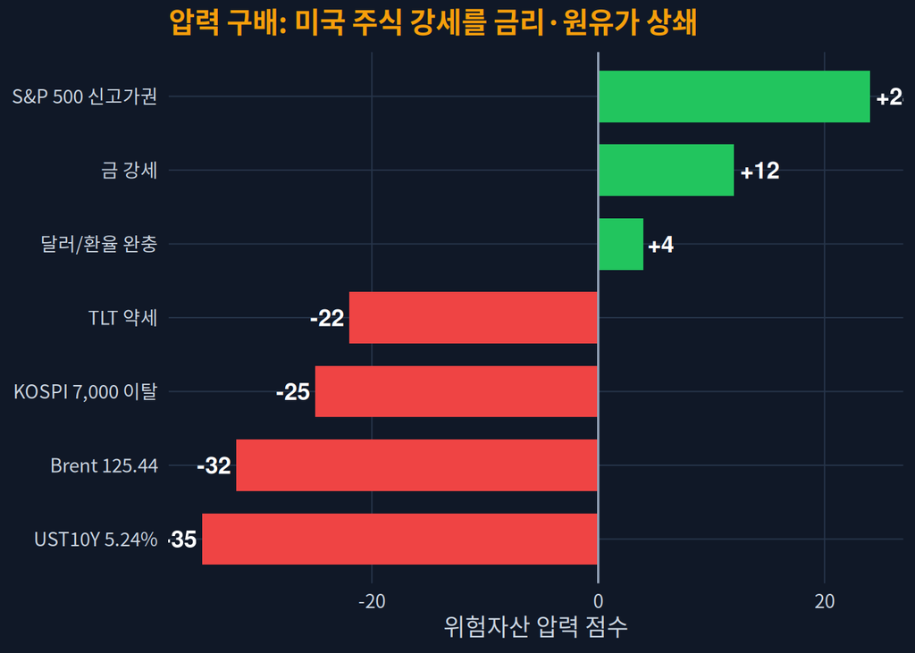

그림 5: 그림 5. 매크로 압력 점수. 양수는 위험자산에 우호, 음수는 비용·할인율·변동성 압력.

# 5. 연금·장기계좌 리밸런싱 시사점

이 섹션은 개인별 연금 포트폴리오 제안이 아니라 **장기·절세계좌에서 점검할 위험원**이다.

- KOSPI가 7,000선을 이탈했으므로 국내주식 비중은 “싸졌으니 무조건 확대”가 아니라 **목표비중 대비 초과·미달만 확인**한다.
- 10년물 5%대에서는 장기채 ETF가 방어자산처럼 움직이지 않을 수 있다. 채권은 **만기·듀레이션별로 분리**해 본다.
- 유가 125달러권은 물가·마진·운송비를 동시에 자극한다. 성장주와 소비주를 같은 위험묶음으로 두지 않는다.
- 금은 방어자산 역할이 살아났지만, 가격 급등 뒤에는 분할 리밸런싱 원칙이 더 중요하다.

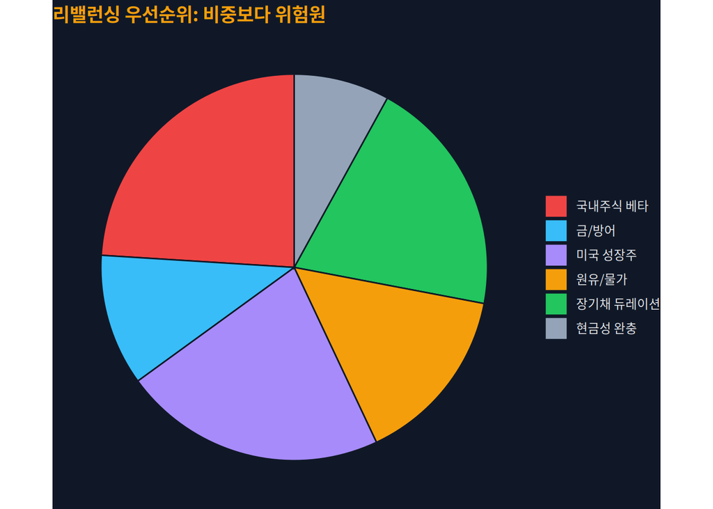

그림 6: 그림 6. 장기계좌 위험예산 점검 예시. 권고 비중이 아니라 이번 레짐에서 먼저 봐야 할 위험원이다.

# 6. 모의투자 성과 복기

최근 저장소에서 확인되는 모의투자 관련 공개 수치는 전월 저널과 동일하게 9월 초 리셋 이후 상태가 마지막이다.

- 9월 2일 리셋 후 9월 4일 기준 총평가액 `97,194,771원`, 리셋 대비 `+1.97%`.
- 금 포지션 전량 매도 실현 `+1,592,460원`, `+3.05%`.
- 복원 후 배분은 KODEX200 약 `55.0%`, TIGER 미국나스닥100 약 `44.5%`.

10월 시장에 대입하면, 이 바스켓은 **KOSPI 하락에 취약하지만 미국 나스닥과 환율 완충이 일부 방어하는 구조**다. 다음 점검에서는 평가금액보다 `주문 실패율`, `평균이익/평균손실`, `profit factor`, `최대낙폭`을 월간 표준 지표로 고정해야 한다.

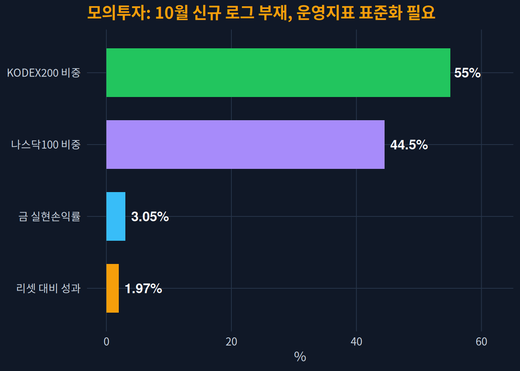

그림 7: 그림 7. 모의투자 최근 공개 상태. 10월 신규 체결 로그가 없어 9월 초 리셋 이후 확인치로 고정했다.

# 7. Claude vs Codex 예측모델 성과

`data/hit_rate_history.json`의 마지막 공개 채점표는 2026년 5월 4주 `57%`이며, 3월 말~5월 말 평균은 약 `61.7%`다. 저장소의 최근 KOSPI 논문·라운드넘버 모델 산출물은 모델링 구조를 강화했지만, 10월 시가·종가 예측의 신규 승패표는 아직 없다.

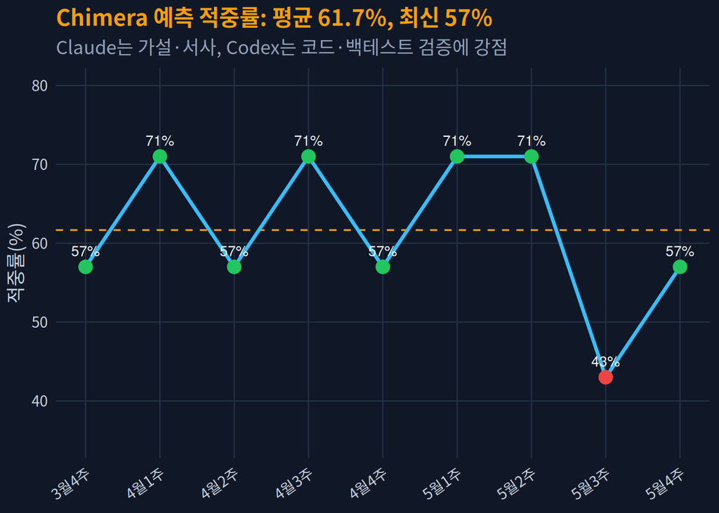

그림 8: 그림 8. 저장소 hit_rate_history.json 기준 예측 적중률. 10월 신규 채점표가 아니라 마지막 공개 내부 이력이다.

현재 운영 판정은 다음과 같다.

- **Claude**: 시장 레짐 서사, 반증조건, 리스크 설명에 강하다.
- **Codex**: 데이터 파이프라인, 룩어헤드 제거, 렌더·배포 자동화에 강하다.
- **검증 원칙**: LAG=0 성과는 룩어헤드 가능성이 있어 폐기하고, LAG=1 이상만 비교한다.

# 8. 이번 달 결론

10월의 핵심은 **미국 주식이 강하다는 사실보다, 그 강세가 10년물 5%대와 Brent 125달러권을 견디며 만들어졌다는 점**이다. KOSPI는 7,000선을 다시 잃었고, 국내 ETF 베타는 미국 ETF보다 취약하다. 장기계좌와 모의투자에서는 수익률 추격보다 위험원 분리, 리밸런싱 날짜 고정, 신규 예측모델 채점표 복원이 우선이다.

**노트다음 발행 전 확인할 것**

1. KRX에서 KOSPI·KOSDAQ·업종별 공식 월간 표를 확보한다.
2. ETF 운용사 공식 PDF/CSV로 NAV, 괴리율, 분배금을 갱신한다.
3. 모의투자 로그와 Claude vs Codex 일별 예측 승패표를 10월 월말판에 추가한다.